# LIME walk-through Part 1:

## Binary Classification of Text Documents

## 1: Introduction

In this series of notebooks, we will see how the `lime` module can be used to implement the methodology described in Ribeiro et al (2016) "Why Should I Trust You?: Explaining the Perdictions of Any Classifier". We will use the implementation of LIME in python to explain individual predictions from several classifiers.

These walk-throughs are adapted from the tutorials created by the package developers, which are available on their [github page](https://github.com/marcotcr/lime).

In this first walk-through we will explore how LIME can be used to interpret a classifier for text documents when there are only two document classed. In the second walk-though we will extend this to consider multiple document classes. In the third and final walk-through, we will look at some more conventional, tabular data that have numeric values.

If you would like to explore these ideas on other types of data, such as images, tutorials for these explainers can be found on the github page linked above.

## 2: Set up

This notebook has several dependancies, which can be loaded as follows:

```python
import lime
import sklearn
import numpy as np
import sklearn
import sklearn.ensemble
import sklearn.metrics
from __future__ import print_function
```

## 3: Fetching the data and training a classifier

### 3.1: Fetching the data

In this first walk-through we will be using the [20 newsgroups dataset](https://scikit-learn.org/0.19/datasets/twenty_newsgroups.html). The 20 newsgroups dataset comprises around 18000 newsgroups posts on 20 topics split in two subsets: one for training (or development) of a model and the other one for testing (or for performance evaluation) of the model. The split between the train and test set is based upon whether a message is posted before or after a specific date.

The 20 newsgroups dataset is included in scikit-learn (`sklearn`) and, in this walk-through, we will focus on only two of the categories: `alt.atheism` and `soc.religion.christian`. We can use the following code to load and store both the training and test data relating to these categories. We also create some more readable names for the two classes of document.

```python
from sklearn.datasets import fetch_20newsgroups
categories = ['alt.atheism', 'soc.religion.christian']
class_names = ['atheism', 'christian']

newsgroups_train = fetch_20newsgroups(subset='train', categories=categories)
newsgroups_test = fetch_20newsgroups(subset='test', categories=categories)
```

#### TASK 01

Print element 0 of the training data `newsgroups_train.data`. What form does this take?

Print the training labels `newsgroup_train.target`. What form do these take?

How many training examples are there on the topic of Atheism or Christianity?

#### SOLUTION 1

```python
# YOUR CODE GOES HERE
```

*YOUR TEXT GOES HERE (DOUBLE-CLICK TO EDIT)*

### 3.2: Training the classifier

To turn the text strings into something more ammenable to computation we will apply the tfidf vectoriser. This converts the string into a numeric vector.

#### TASK 02

Search online to find what the acronym tfidf stands for.

#### SOLUTION 02

*YOUR TEXT GOES HERE*

#### TASK 03

Find out how the tfidf vectoriser converts a string to a numeric vector.

#### SOLUTION 03

*YOUR TEXT GOES HERE (DOUBLE-CLICK TO EDIT)*

You can include LaTeX in singe dollar quotes for inline $e^{\pi i} - 1 = 0$ or double dollar quotes for displayed math:

$$e^{\pi i} - 1 = 0.$$

To apply this transformation to our training and test data, we first have to create a vectorizer object and then use this to create our training and test vectors. _Note that we use `vectorizer.fit_transform` for the training data and `vectorizer.transform` for the test data._

```python
vectorizer = sklearn.feature_extraction.text.TfidfVectorizer(lowercase=False)
train_vectors = vectorizer.fit_transform(newsgroups_train.data)
test_vectors = vectorizer.transform(newsgroups_test.data)
```

Now that we have our training and test data in a suitable form, we can fit a random forest to the training data and use it to predict the classes of the test data.

You may or may not already know what a random forest is, either way is perfectly fine. You will learn more about such classification methods later this year during the supervised learning course. If you already know about random forests, then you will be aware that it can be very difficult to understand how a fitted random forest model obtains its predictions. This makes predictions based on this type of model difficult to explain to a client, a stakeholder or a (dis-)satisfied customer. On the other hand, if you do not yet know about random forests then you are in the same position as that client, stakeholder or customer. You are in the perfect place to see how LIME can provide an intuition for the a prediction made by a random forest.

Fitting the random forest is simple using the functionality built into `sklearn`.

```python
rf = sklearn.ensemble.RandomForestClassifier(n_estimators=500)
rf.fit(train_vectors, newsgroups_train.target)
```

```
RandomForestClassifier(n_estimators=500)
```

We can now use the trained random forest classifier to predict the class of each document in the test set; namely whether it relates to Christian or Atheist content. We can evaluate the quality of these predictions using the F-score, which takes values between 0 and 1.

```python
pred = rf.predict(test_vectors)
sklearn.metrics.f1_score(newsgroups_test.target, pred, average ='binary')
```

```
0.915606936416185
```

#### TASK 05

Calculate the proportion of the test documents that our random forest classifier predicts correctly.

#### SOLUTION 05

```python
# YOUR CODE GOES HERE
```

#### TASK 06

Why does this differ from the F score?

#### SOLUTION 06

*YOUR TEXT GOES HERE (DOUBLE-CLICK TO EDIT)*

The [sklearn page on the 20 newsgroups data](https://scikit-learn.org/0.19/datasets/twenty_newsgroups.html#filtering-text-for-more-realistic-training) shows that another, easily explained, classifier overfits this dataset by basing its predictions on irrelevant parts of the text such as headers. We will use LIME to see if random forests do the same.

### 3.3 Explaining predictions using LIME

The `lime` module explainer functions for text data assumes that the classifier acts on raw text. However, we have used a random forest classifier from sklearn, which used a vectorised form of the text. To get around this issue, we will create a pipleline (a functionality from sklearn to combine multiple operations) to implement `predict_proba` on `raw_text` lists.

We can then use this pipeline to find the probability that each test document belongs to the class `atheism` or `christian`.

```python
from sklearn.pipeline import make_pipeline
c = make_pipeline(vectorizer, rf)
print(c.predict_proba([newsgroups_test.data[0]]))
```

```
[[0.282 0.718]]
```

#### TASK 07

What is the estimated probability that the final test document is `christian`? What is the estimated probability that the penultimate test document is about `atheism`?

#### SOLUTION 07

```python
# YOUR CODE GOES HERE
```

The random forest classifier predicts that the final document belongs to the `christian` class with probability 0.802. Similarly, the penultimate document is predicted to belong to the `atheism` class with probability 0.094.

We now use LIME to explain these predictions. To do this we create an `explainer` object from the `lime` module. To make the resulting output prettier, we pass this object the vector of `class_names` that we created at the start of this walk-through.

```python
from lime import lime_text
from lime.lime_text import LimeTextExplainer

explainer = LimeTextExplainer(class_names=class_names)
```

We can then use this explainer object to generate an explanation for any document in the test set. In doing this, we will limit ourselves to having at most 6 explaining features in any explanation.

```python
index = 1
exp = explainer.explain_instance(newsgroups_test.data[index], c.predict_proba, num_features=6)

print('Document id: %d' % index)
print('Predicted class:', class_names[c.predict([newsgroups_test.data[index]])[0]])
print('Probability(Christian) =', c.predict_proba([newsgroups_test.data[index]])[0,1])
print('True class: %s' % class_names[newsgroups_test.target[index]])

exp.as_list()
```

```
Document id: 1
Predicted class: christian
Probability(Christian) = 0.694
True class: christian
```

```
[('morality', -0.03623410878020443),
 ('alt', -0.02668300511149029),
 ('clh', 0.02113716367118045),
 ('try', -0.018490975208987754),
 ('atheist', -0.017900625547372685),
 ('don', -0.016461912580042704)]
```

The random forest correctly identified the first test document as being `christian`, and did so with fairly high probability.

The LIME explanation of this prediction is presented as a list of weighted features. These weighted features represents a linear model that approximates the local behaviour of the random forest classifier in the vicinity of the test document.

Recall that this local linear model is only an approximation. Let's check and see how much the probability of Christianity really changes when these words are removed.

```python
print('Original prediction:', rf.predict_proba(test_vectors[index])[0,1])
tmp = test_vectors[index].copy()
tmp[0,vectorizer.vocabulary_['morality']] = 0 # set word count for 'morality' to 0
tmp[0,vectorizer.vocabulary_['alt']] = 0      # set word count for 'alt' to 0
print('Prediction removing "morality" and "alt":', rf.predict_proba(tmp)[0,1])
print('Difference in probability:', rf.predict_proba(tmp)[0,1] - rf.predict_proba(test_vectors[index])[0,1])
```

```
Original prediction: 0.694
Prediction removing "morality" and "alt": 0.752
Difference in probability: 0.05800000000000005
```

The predicted change from our LIME explainer is pretty close to the true change!

### Visualising our LIME explanations

There are two main ways to visualise our explanations. The first is to return the explainer as a matplotlib barplot. This makes our list object much nicer to interpret.

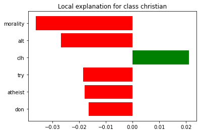

```python
%matplotlib inline
fig = exp.as_pyplot_figure()
```

Alternatively, we can export the visualisation as an hmtl page using D3.js to render the graphs. This html page can be rendered nicely in a notebook environment as follows.

```python
exp.show_in_notebook(text=False)
```

[output not shown]

Alternatively, it can be saved as a stand-alone html file.

```python
exp.save_to_file('explainer_1.html')
```

Finally, we can also include a visualisation of the originial document, with the words in the explanation highlighted according to which class they suggest. Notice that not all of these words are particularly sensible but that `alt`, which seemed non-sensical when taken out of context, is actually a posting tag that may well generalise to classification of other posts.

```python
exp.show_in_notebook(text=True)
```

[output not shown]

#### TASK 08

Create and interpret a visualisation of the top 5 words explaining the final post in the test set.

#### SOLUTION 08

```python
# YOUR CODE GOES HERE
```

*YOUR TEXT GOES HERE (DOUBLE-CLICK TO EDIT)*

#### TASK 09

Create and interpret a visualisation of the top 7 words explaining the post at index 300 in the test set.

#### SOLUTION 09

```python
# YOUR CODE GOES HERE
```

*YOUR TEXT GOES HERE (DOUBLE-CLICK TO EDIT)*

Note that while we have used a random forest classifier in this example, the `lime` module will work with any classifier that has a `predict_proba` method. In the next walkthrough we will consider using the LIME explainer with a different classifier and a multi-class problem.

End of File.